# chapter6

2023-12-11

# Analysis of longitudinal data

## Analysis of the RATS data

In the first part, I will analyse the RATS data, by providing graphical summaries and using linear mixed model.

```r
#read the data

RATS <- read.csv("RATS.csv")

#summary of the rats data
summary(RATS)
```

```
##        X                ID            Group          days
##  Min.   :  1.00   Min.   : 1.00   Min.   :1.00   Length:176
##  1st Qu.: 44.75   1st Qu.: 4.75   1st Qu.:1.00   Class :character
##  Median : 88.50   Median : 8.50   Median :1.50   Mode  :character
##  Mean   : 88.50   Mean   : 8.50   Mean   :1.75
##  3rd Qu.:132.25   3rd Qu.:12.25   3rd Qu.:2.25
##  Max.   :176.00   Max.   :16.00   Max.   :3.00
##       RATS            Time
##  Min.   :225.0   Min.   : 1.00
##  1st Qu.:267.0   1st Qu.:15.00
##  Median :344.5   Median :36.00
##  Mean   :384.5   Mean   :33.55
##  3rd Qu.:511.2   3rd Qu.:50.00
##  Max.   :628.0   Max.   :64.00
```

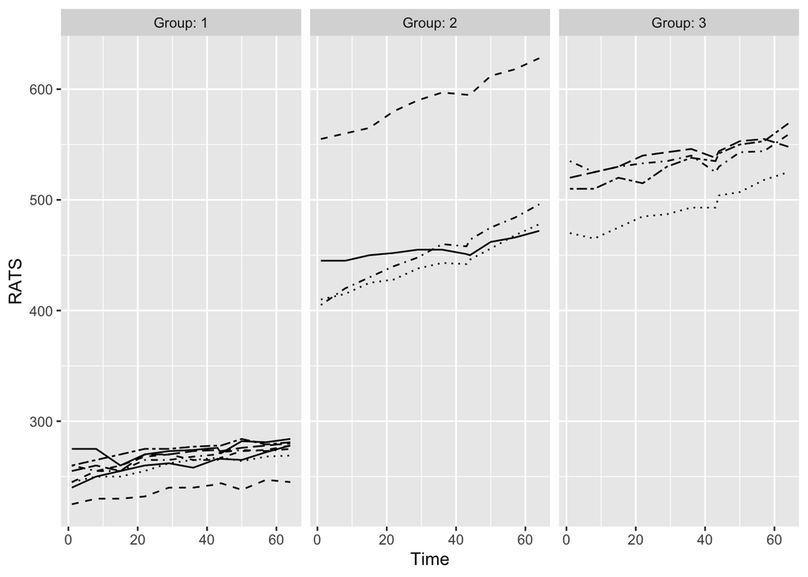

```r
#Access the package ggplot2
library(ggplot2)
RATS$Group <- factor(RATS$Group)
RATS$ID <- factor(RATS$ID)

# Draw the plot
ggplot(RATS, aes(x = Time, y = RATS, linetype = ID)) +
  geom_line() +
  scale_linetype_manual(values = rep(1:10, times=4)) +
  facet_grid(. ~ Group, labeller = label_both) +
  theme(legend.position = "none") +
  scale_y_continuous(limits = c(min(RATS$RATS), max(RATS$RATS)))
```

I started by loading the data. the dataset contains longitudinal information on rats’ weights.

It seems that in group 2 and 3 the starting weight is much higher than in group1. The increase seems to be about the same.

Next, I will get the group means for different timepoints and draw a plot on that data.

```r
# Create a summary data by treatment and subject with mean as the summary variable (ignoring baseline week 0)
library(dplyr)
library(tidyr)

#stabdardize the data
RATSS <- RATS %>%
  group_by(Time) %>%
  mutate( stdRATS = (RATS - mean(RATS))/sd(RATS)) %>%
  ungroup()


#number of participants per group
RATSS$n <- ifelse(RATSS$Group == 1, 8, 4)

#calculate standard error
RATSS1 <- RATSS %>%
  group_by(Group, Time) %>%
  summarise(mean = mean(RATS), se = sd(RATS)/sqrt(n) )%>%
  ungroup()
```

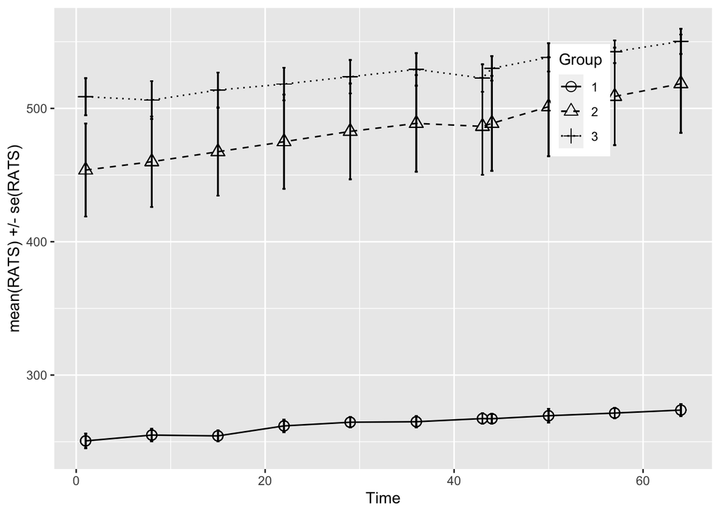

```r
# Plot the mean profiles
library(ggplot2)
ggplot(RATSS1, aes(x = Time, y = mean, linetype = Group, shape = Group)) +
  geom_line() +
  scale_linetype_manual(values = c(1,2,3)) +
  geom_point(size=3) +
  scale_shape_manual(values = c(1,2,3)) +
  geom_errorbar(aes(ymin=mean-se, ymax=mean+se, linetype="1"), width=0.3) +
  theme(legend.position = c(0.8,0.8)) +
  scale_y_continuous(name = "mean(RATS) +/- se(RATS)")
```

Group 1 has smaller standard errors as other groups. This plot does not give much more information than the previous, group 2 and 3 probably increase a little faster than group 1.

Checking data outliers

```r
# Create a summary data by treatment and subject with mean as the summary variable (ignoring baseline week 0)
RATS1 <- RATS %>%
  filter(Time > 1) %>%
  group_by(Group, ID) %>%
  summarise( mean=mean(RATS) ) %>%
  ungroup()
RATSS1 <- RATSS %>%
  group_by(Group, Time) %>%
  summarise(mean = mean(RATS), se = sd(RATS)/sqrt(n) )%>%
  ungroup()
```

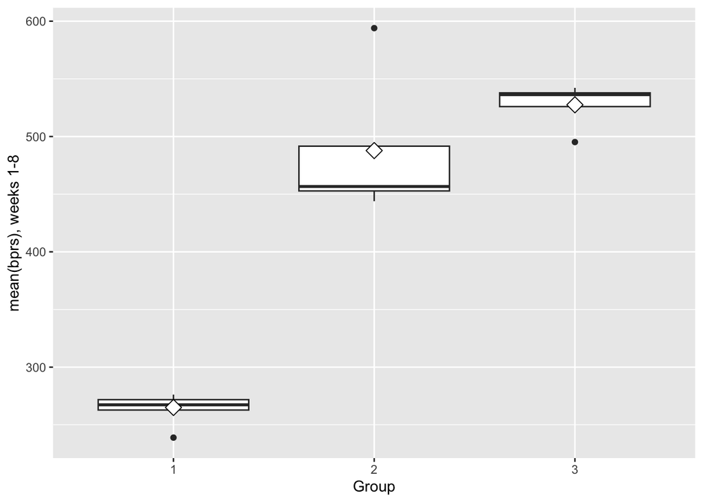

```r
ggplot(RATS1, aes(x = Group, y = mean)) +
  geom_boxplot() +
  stat_summary(fun = "mean", geom = "point", shape=23, size=4, fill = "white") +
  scale_y_continuous(name = "mean(bprs), weeks 1-8")
```

T test sould not be performed as there are 3 groups, but lets do the anova.

```r
# Add the baseline from the original data as a new variable to the summary data
RATS2 <- RATS1 %>%
  mutate(baseline = RATS[RATS$Time == 1,]$RATS)

# Fit the linear model with the mean as the response
fit <- lm(mean ~ baseline + Group, data = RATS2)

anova(fit)
```

```
## Analysis of Variance Table
##
## Response: mean
##           Df Sum Sq Mean Sq   F value   Pr(>F)
## baseline   1 253625  253625 1859.8201 1.57e-14 ***
## Group      2    879     439    3.2219  0.07586 .
## Residuals 12   1636     136
## ---
## Signif. codes:  0 '***' 0.001 '**' 0.01 '*' 0.05 '.' 0.1 ' ' 1
```

## Analysis of BPRS data

First, load the data and plot the ratings per weeks.

```r
#read the data

BPRS <- read.csv("BPRS.csv")

#summary of the BPRS data
summary(BPRS)
```

```
##        X            treatment      subject         weeks
##  Min.   :  1.00   Min.   :1.0   Min.   : 1.00   Length:360
##  1st Qu.: 90.75   1st Qu.:1.0   1st Qu.: 5.75   Class :character
##  Median :180.50   Median :1.5   Median :10.50   Mode  :character
##  Mean   :180.50   Mean   :1.5   Mean   :10.50
##  3rd Qu.:270.25   3rd Qu.:2.0   3rd Qu.:15.25
##  Max.   :360.00   Max.   :2.0   Max.   :20.00
##       BPRS            week
##  Min.   :18.00   Min.   :0
##  1st Qu.:27.00   1st Qu.:2
##  Median :35.00   Median :4
##  Mean   :37.66   Mean   :4
##  3rd Qu.:43.00   3rd Qu.:6
##  Max.   :95.00   Max.   :8
```

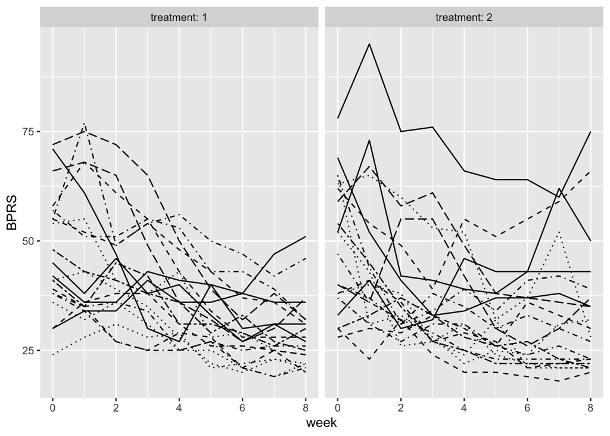

```r
#Access the package ggplot2
library(ggplot2)
BPRS$treatment <- factor(BPRS$treatment)
BPRS$subject <- factor(BPRS$subject)

# Draw the plot
ggplot(BPRS, aes(x = week, y = BPRS, linetype = subject)) +
  geom_line() +
  scale_linetype_manual(values = rep(1:10, times=4)) +
  facet_grid(. ~ treatment, labeller = label_both) +
  theme(legend.position = "none") +
  scale_y_continuous(limits = c(min(BPRS$BPRS), max(BPRS$BPRS)))
```

Rating seem to be decreasing in both groups. Variability also decreasing.

Next let’s create the regression model.

```r
model1 <- lm(BPRS ~ treatment + week, data = BPRS)
model1
```

```
##
## Call:
## lm(formula = BPRS ~ treatment + week, data = BPRS)
##
## Coefficients:
## (Intercept)   treatment2         week
##     46.4539       0.5722      -2.2704
```

It shows large covariance with time and smaller with treatment groups. This means ratings are strongly decreasing as time goes and treament group 2 have littel higher scores.

Next, The Random Intercept Model.

```r
# access library lme4
library(lme4)
# Create a random intercept model
BPRS_ref <- lmer(BPRS ~ week + treatment + (1 | subject), data = BPRS, REML = FALSE)

summary(BPRS_ref)
```

```
## Linear mixed model fit by maximum likelihood  ['lmerMod']
## Formula: BPRS ~ week + treatment + (1 | subject)
##    Data: BPRS
##
##      AIC      BIC   logLik deviance df.resid
##   2748.7   2768.1  -1369.4   2738.7      355
##
## Scaled residuals:
##     Min      1Q  Median      3Q     Max
## -3.0481 -0.6749 -0.1361  0.4813  3.4855
##
## Random effects:
##  Groups   Name        Variance Std.Dev.
##  subject  (Intercept)  47.41    6.885
##  Residual             104.21   10.208
## Number of obs: 360, groups:  subject, 20
##
## Fixed effects:
##             Estimate Std. Error t value
## (Intercept)  46.4539     1.9090  24.334
## week         -2.2704     0.2084 -10.896
## treatment2    0.5722     1.0761   0.532
##
## Correlation of Fixed Effects:
##            (Intr) week
## week       -0.437
## treatment2 -0.282  0.000
```

Model quality seems to be high. similarly fixed effects show the same correlations.

Next, Random Slope Model and comparing it to the intercept model.

```r
#random slope model
BPRS_ref1 <- lmer(BPRS ~ week + treatment + (week | subject), data = BPRS, REML = FALSE)
#comparison with anova
anova(BPRS_ref, BPRS_ref1)
```

```
## Data: BPRS
## Models:
## BPRS_ref: BPRS ~ week + treatment + (1 | subject)
## BPRS_ref1: BPRS ~ week + treatment + (week | subject)
##           npar    AIC    BIC  logLik deviance  Chisq Df Pr(>Chisq)
## BPRS_ref     5 2748.7 2768.1 -1369.4   2738.7
## BPRS_ref1    7 2745.4 2772.6 -1365.7   2731.4 7.2721  2    0.02636 *
## ---
## Signif. codes:  0 '***' 0.001 '**' 0.01 '*' 0.05 '.' 0.1 ' ' 1
```

```r
summary(BPRS_ref1)
```

```
## Linear mixed model fit by maximum likelihood  ['lmerMod']
## Formula: BPRS ~ week + treatment + (week | subject)
##    Data: BPRS
##
##      AIC      BIC   logLik deviance df.resid
##   2745.4   2772.6  -1365.7   2731.4      353
##
## Scaled residuals:
##     Min      1Q  Median      3Q     Max
## -2.8919 -0.6194 -0.0691  0.5531  3.7976
##
## Random effects:
##  Groups   Name        Variance Std.Dev. Corr
##  subject  (Intercept) 64.8222  8.0512
##           week         0.9609  0.9802   -0.51
##  Residual             97.4305  9.8707
## Number of obs: 360, groups:  subject, 20
##
## Fixed effects:
##             Estimate Std. Error t value
## (Intercept)  46.4539     2.1052  22.066
## week         -2.2704     0.2977  -7.626
## treatment2    0.5722     1.0405   0.550
##
## Correlation of Fixed Effects:
##            (Intr) week
## week       -0.582
## treatment2 -0.247  0.000
```

Next, lets add the intercept of time and treatment group

```r
BPRS_ref2 <- lmer(BPRS ~ week + treatment + (week | subject) + week*treatment, data = BPRS, REML = FALSE)

anova(BPRS_ref1, BPRS_ref2)
```

```
## Data: BPRS
## Models:
## BPRS_ref1: BPRS ~ week + treatment + (week | subject)
## BPRS_ref2: BPRS ~ week + treatment + (week | subject) + week * treatment
##           npar    AIC    BIC  logLik deviance  Chisq Df Pr(>Chisq)
## BPRS_ref1    7 2745.4 2772.6 -1365.7   2731.4
## BPRS_ref2    8 2744.3 2775.4 -1364.1   2728.3 3.1712  1    0.07495 .
## ---
## Signif. codes:  0 '***' 0.001 '**' 0.01 '*' 0.05 '.' 0.1 ' ' 1
```

```r
summary(BPRS_ref2)
```

```
## Linear mixed model fit by maximum likelihood  ['lmerMod']
## Formula: BPRS ~ week + treatment + (week | subject) + week * treatment
##    Data: BPRS
##
##      AIC      BIC   logLik deviance df.resid
##   2744.3   2775.4  -1364.1   2728.3      352
##
## Scaled residuals:
##     Min      1Q  Median      3Q     Max
## -3.0512 -0.6271 -0.0768  0.5288  3.9260
##
## Random effects:
##  Groups   Name        Variance Std.Dev. Corr
##  subject  (Intercept) 64.9964  8.0620
##           week         0.9687  0.9842   -0.51
##  Residual             96.4707  9.8220
## Number of obs: 360, groups:  subject, 20
##
## Fixed effects:
##                 Estimate Std. Error t value
## (Intercept)      47.8856     2.2521  21.262
## week             -2.6283     0.3589  -7.323
## treatment2       -2.2911     1.9090  -1.200
## week:treatment2   0.7158     0.4010   1.785
##
## Correlation of Fixed Effects:
##             (Intr) week   trtmn2
## week        -0.650
## treatment2  -0.424  0.469
## wek:trtmnt2  0.356 -0.559 -0.840
```

Fits ok but not significant.

Last, plotting with raw and fitted values.

[figure not shown]

```r
#raw values
ggplot(BPRS, aes(x = week, y = BPRS, group = subject)) +
  geom_line() +
  scale_x_continuous(name = "Time (weeks)", breaks = seq(0, 60, 20)) +
  scale_y_continuous(name = "scores") +
  theme(legend.position = "top")
```

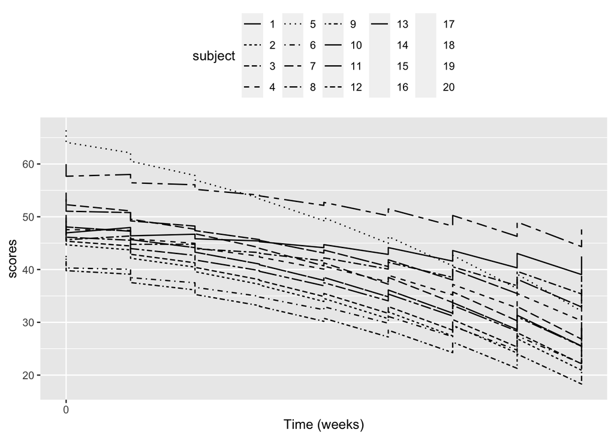

```r
Fitted <- fitted(BPRS_ref2)

BPRS$fitted <- Fitted

#with fitted values
ggplot(BPRS, aes(x = week, y = fitted, group = subject)) +
  geom_line(aes(linetype = subject)) +
  scale_x_continuous(name = "Time (weeks)", breaks = seq(0, 60, 20)) +
  scale_y_continuous(name = "scores") +
  theme(legend.position = "top")
```

Fitted values produce clearer plot as the values are adjusted for time and treatment group. Scores are decreasing as time goes